# Fundamental of `NumPy`

```python
import numpy as np
my_arr = np.arange(1000000)
my_list = list(range(1000000))
```

```python
%time for _ in range(10): my_arr2 = my_arr * 2
```

```
Wall time: 13 ms
```

```python
%time for _ in range(10): my_list2 = [x * 2 for x in my_list]
```

```
Wall time: 563 ms
```

#### From the above example, you may notice that, the speed of `NumPy` is much faster than pure `Python`

## 1. `ndarray` in `NumPy`

- `ndarray` stands for an n-dimensional array

```python
data = np.random.randn(2,3)
data
```

```
array([[-1.96493908, -1.07471975, -0.59076667],
       [ 0.61140007,  1.07507367,  1.11946093]])
```

```python
%time data * 10
```

```
Wall time: 0 ns
```

```
array([[-19.64939079, -10.74719747,  -5.90766666],
       [  6.11400073,  10.7507367 ,  11.19460933]])
```

```python
%time data + data
```

```
Wall time: 0 ns
```

```
array([[-3.92987816, -2.14943949, -1.18153333],
       [ 1.22280015,  2.15014734,  2.23892187]])
```

`ndarray` is an multi-dimensional container with **homogeneous data**, which means all elements within a `ndarray` must belong to a same type.  
Every array have a `shape` property(a tuple showing the dimensional info) and a `dtype` property(a object showing the data type)

```python
data.shape
```

```
(2, 3)
```

```python
data.dtype
```

```
dtype('float64')
```

### Create `ndarray`

- it accept all list type object

```python
data1 = [6,7.5,8,0,1]
arr1 = np.array(data1)
arr1
```

```
array([6. , 7.5, 8. , 0. , 1. ])
```

#### nested list would be converted to a multiple-dimensional array

```python
data2 = [[1,2,3,4],[5,6,7,8]]
arr2 = np.array(data2)
arr2
```

```
array([[1, 2, 3, 4],
       [5, 6, 7, 8]])
```

- `ndim`: show the dimensional info
- `shape`: also the dimensional info

```python
arr2.ndim
```

```
2
```

```python
arr2.shape
```

```
(2, 4)
```

```python
print(arr1.dtype)
print(arr2.dtype)
```

```
float64
int32
```

### We could also use the following methods to create array

- `zeros`
- `ones`
- `empty`
- Just need to input a tuple indicates the `shape` info

```python
np.zeros(10)
```

```
array([0., 0., 0., 0., 0., 0., 0., 0., 0., 0.])
```

```python
np.zeros((3,6))
```

```
array([[0., 0., 0., 0., 0., 0.],
       [0., 0., 0., 0., 0., 0.],
       [0., 0., 0., 0., 0., 0.]])
```

```python
np.empty((2,3,2))
```

```
array([[[6.23042070e-307, 1.89146896e-307],
        [1.37961302e-306, 6.23053614e-307],
        [6.23053954e-307, 9.34609790e-307]],

       [[8.45593934e-307, 9.34600963e-307],
        [1.86921143e-306, 6.23061763e-307],
        [1.33511562e-306, 6.89805151e-307]]])
```

#### `arrange` could crate a sequence

```python
np.arange(15)
```

```
array([ 0,  1,  2,  3,  4,  5,  6,  7,  8,  9, 10, 11, 12, 13, 14])
```

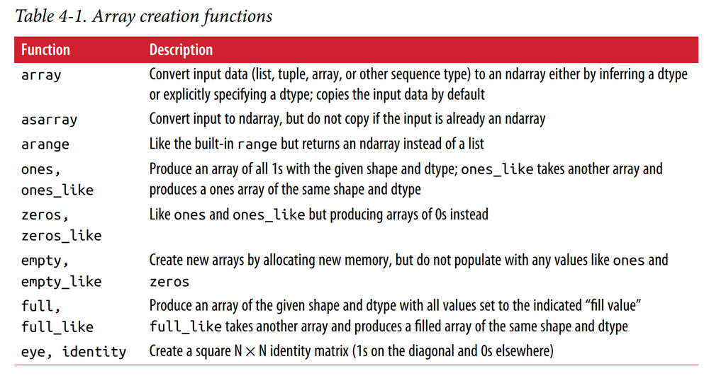